# Using agents in scientific research

Basel, November 2026

Isidora Araya Day

Donostia International Physics Center

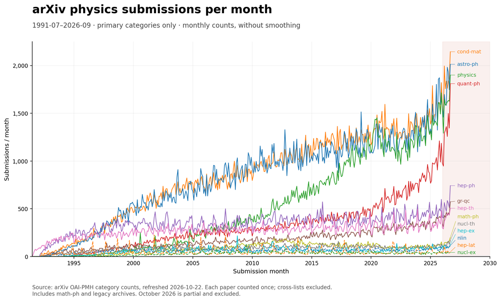

Source: [tecunningham/ai-discovery-data · output-arxiv](https://github.com/tecunningham/ai-discovery-data/tree/main/problems/output-arxiv)

your computer · ~/Projects/ai-discovery-data

ai-discovery-data

What should we work on?

Inspect this repo, focus on the output-arxiv section. Collect the data and make a plot of physics submissions per month as a function of time. Show full physics aggregated submissions, and also add a curve per category.

Working for 0s Worked for 4m 14s **›**

I’ll inspect the `output-arxiv` data, check how categories and dates are recorded, and build a monthly plot with the physics total and category curves.

>_ Ran 0 commands

The repo already contains monthly primary-category counts, so each paper can be counted once without duplicating cross-lists. I’ll use July 1991–July 2026; August 2026 is partial in this snapshot.

ai-discovery-data/problems/output-arxiv/analyze_physics.py

Created the plot from the repo’s existing snapshot: **July 1991–July 2026**, with the physics total and all **13 physics archives**. Each paper counts once by primary category; partial August 2026 is excluded.

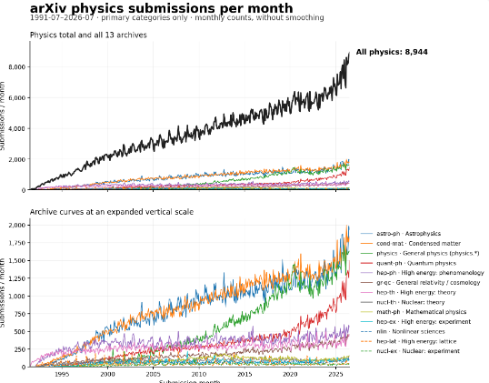

↑

analyze_physics.py — ai-discovery-data

▾ai-discovery-data

▾.cache

▾output-arxiv-physics

arxiv-physics-monthly.png

arxiv-physics-archives-by-month.csv

›lib

▾problems

›math-erdos

▾output-arxiv

analyze_physics.py*U*

arxiv-categories-by-month.csv

chart_spec.py

fetch.py

figure.py

README.md

CLAUDE.md

README.md

analyze_physics.py *U*

**50**def collect(): **51** """Return a continuous monthly grid and normalized primary-category counts.""" **52** with SOURCE.open(newline="") as stream: **53** rows = list(csv.DictReader(stream)) **54** cutoff = AS_OF_DATE.strftime("%Y-%m") **55** if max(r["month"] for r in rows) != cutoff: **56** raise ValueError("Recheck snapshot coverage and its partial-month cutoff") **57** counts = defaultdict(lambda: defaultdict(int)) **58** seen = set() **59** for row in rows: **60** key = row["month"], row["category"] **61** if key in seen: **62** raise ValueError(f"Duplicate input row: {key}") **63** seen.add(key) **64** value = int(row["submissions"]) **65** if value < 0: **66** raise ValueError(f"Negative submissions: {key}") **67** category = ARXIV_LEGACY.get(row["category"], row["category"]) **68** if category.split(".")[0] in ARXIV_PHYSICS: **69** if "1991-07" <= row["month"] < cutoff: **70** counts[category][row["month"]] += value

The data, the code, and the figures are **on your computer**.

# How do we continue to produce high quality research?

- How do we check all this?
- Are LLMs really powerful in research?
- How do we choose what to work on?

# Agents in the lab

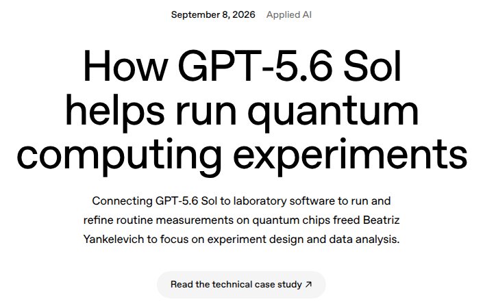

Connected to the lab software, researchers use GPT-5.6 Sol to run **routine qubit measurements**.

[OpenAI, Sep 2026 ↗](https://openai.com/index/codex-quantum-computing-experiments/)

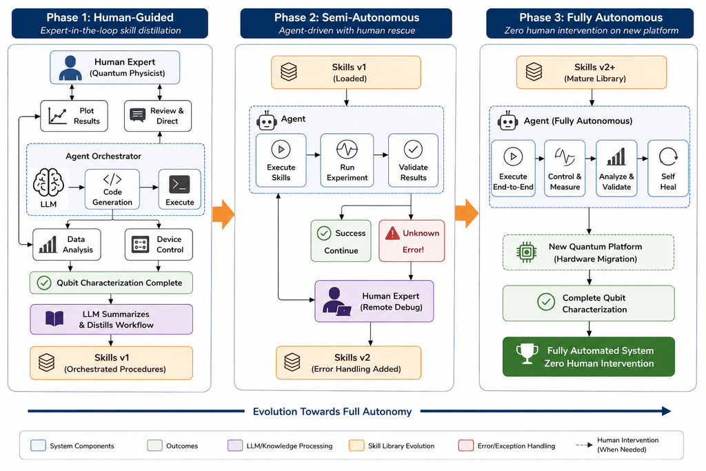

Vibe Calibration: 100 qubits calibrated with LLMs.

[Vibe Calibration, arXiv:2606.22376 ↗](https://arxiv.org/html/2606.22376v1)

# Four ways to work with AI

**Chatbot**  
Ask, use the answer.

**Copilot**  
Write code together.

**Agent**  
Give it a task.

**Agentic workflow**  
It runs research loops.

### Chatbot

[figure not shown]

“How can I reproduce this figure?”

1. You ask and give context.
2. It suggests code.
3. You run it and report back.

**You do each step.**

### Agent

[figure not shown]

“Reproduce this figure in this project.”

1. You set the goal and checks.
2. It reads, writes, and runs code.
3. It checks and revises.

**You review the evidence.**

# What turns an LLM into an agent?

### What it needs

- **Prompt** — Your instruction.
- **Context** — Papers, data, code.
- **Memory** — Notes and decisions.
- **Skills** — Recipes for recurring tasks.
- **Tools** — Files, code, tests.

### How it works

1. **Reason** — Inspect the project.
2. **Act** — Use tools.
3. **Observe** — Check and revise.
4. **Record** — Save how to reproduce.

[figure not shown]

# Start, check, and leave a record

### Start inside the project

~/Projects/majorana-nanowire

$ cd ~/Projects/majorana-nanowire

$ codex

› Inspect this repo, focus on the Kwant scattering setup. Add on-site disorder to the wire. Verify the clean limit still gives B² = Δ² + μ².

### Process

1. **Define the task** — Specify the deliverable and checks.
2. **Inspect outputs** — Ask for figures and explanations.
3. **Verify** — Review benchmarks, tests, and the diff.
4. **Commit and record** — Save accepted changes and next steps.

Every now and then clean up! Identify what steps it is better to outsource to existing packages or code.

# Questions?

# Let’s try agents!

### Plan:

- **Pair up**
- **Prompt:** one result to reproduce from a paper, or add a calculation to a project.
- **Check the result:** against a known result or limit.
- **Ask the agent to write notes**.
- **Identify and create a skill**.

### Example

Create a subfolder and work there.

Read arXiv:1009.5542 and write a research project codebase that aims to qualitatively reproduce the paper figures using tight-binding.

Use it to study the topological phase transition of a crooked disordered nanowire.

Report back with a html summary and a code map of what you implemented.

Keep numerics light and implement basic checks.

Do not trust the paper’s results, it may have errors!

**Using a paid model makes a huge difference.**  
Use Codex or Claude CLI, an app, or combine agents in [**T3 Code**](https://t3.codes/).

# Project structure

### All projects in one folder

```
Projects/
├── majorana-nanowire/
├── another-project/
└── ...
```

### Project workflow

This workflow requires balancing correctness and making progress.

## 1. Organize the project

### Projects / majorana-nanowire

```
majorana-nanowire/
├── .git/
├── README.md
├── AGENTS.md
├── pyproject.toml
├── pixi.lock
├── code/
│   ├── majorana_nanowire/
│   │   ├── system.py
│   │   ├── scattering.py
│   │   └── tests/
│   ├── simulations/
│   ├── results/
├── data/
├── manuscript/
├── notes/
└── slides/
```

### One reproducible research workspace

- **Package** — `majorana_nanowire/` holds the Kwant wire (`system.py`) and $\det r$, $G_\text{th}$ (`scattering.py`).
- **Scripts** — `simulations/` runs calculations; `results/` analyses saved data. Both import the package.
- **Tests** — Check known limits, e.g. the clean phase boundary $B^2 = \Delta^2 + \mu^2$, and catch regressions.
- **Environment** — `pyproject.toml` defines dependencies and tasks; `pixi.lock` pins versions.
- **Research record** — Save data, manuscript, notes, and slides together; document commands in the README and track changes with Git.

Repetitive task → Use a **skill** to set up a project structure!

## 2. Check the results

Automate checks, e.g. with [pytest](https://docs.pytest.org/en/stable/):

- **Known limits**: clean wire, $B^2 = \Delta^2 + \mu^2$
- **Symmetry**: BdG spectrum comes in $\pm E$ pairs
- **Quantization**: invariants are integers
- **Convergence**: system size, lattice spacing
- **Two methods agree**: scattering vs. bulk

To check further we prompt and evaluate.

When it goes wrong · a real session

how do we know that this wont happen again?

We can’t rely on my promising to remember. I ignored an existing instruction, so stronger wording alone is insufficient.

So the honest answer is: **this workflow now enforces the important rules, but the skill itself cannot guarantee future compliance.**

## 3. Finalize the project

What I do:

- Discuss results with collaborators.
- Clean up the code and notes.
- Have my collaborators prompt the project.
- Disclose the use of AI.

The questions I still have:

- Should I read every line of code?
- Can another agent review it for me?
- How many checks are enough to trust the result?
- What results are worth publishing?

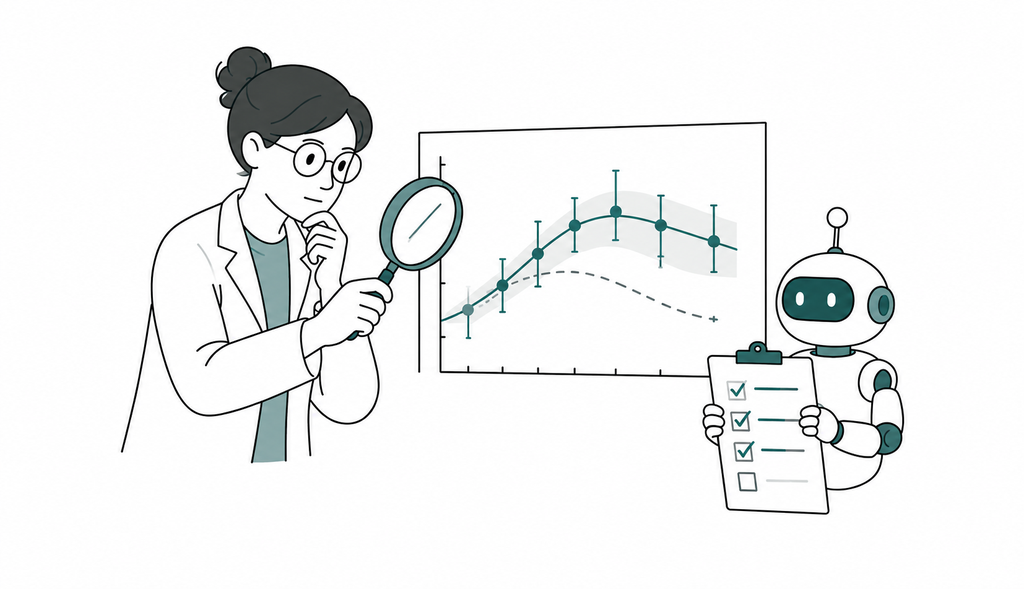

**Producing outputs is easier than knowing whether to trust them.**

# What can become an agent project?

1. **Creating a website**
2. **Scraping a website for data**
3. **Reviewing someone else’s code**
4. **Launching cluster simulations**
5. **Reproducing a figure from a paper**
6. **Generalizing an algorithm**
7. **Testing an idea**
8. **Filling out reimbursement forms**

A project can be **anything with inputs and a deliverable**.

# The cluster, done by an ideal person

1. Test locally that the code runs on a small system.
2. Sync local files with the cluster.
3. Write the cluster scripts.
4. Launch the jobs and track them.
5. If anything fails, find out why, relaunch, keep tracking.
6. Collect the results at the end.
7. Plot and analyze them.

Nobody is this person. Teach codex how to do this using a skill!

# Skills I use the most

Physics & numerics

`born-approximation`112

`tenpy`86

`scientific-coding`33

`pymablock`33

`kwant`28

Cluster runs

`dask-cluster-runbook`129

`bootstrap-direct-slurm-workflow`71

`direct-slurm-cluster-runbook`54

`run-on-io`8

Writing

`technical-writing`99

`render-latex-review-html`58

`quarto`19

`manuscript-writing`18

`figure-design`17

`slide-design`7

Project & code

`clean-up`22

`start-research-project`17

`research-code-map`5

Skill loads per month, 2026

[figure not shown]

Sessions that loaded each skill · my Codex and Claude Code logs, 2026

## Inside a skill: Kwant

~/.codex/skills/kwant/

kwant

SKILL.mdfull file · scroll to explore

**1**---

**2**name: kwant

**3**description: >-

**4** Use this skill when writing or editing research code that uses Kwant for

**5** tight-binding and quantum transport calculations: defining systems, lattices,

**6** shapes, parameterized onsite and hopping functions with params, leads,

**7** solvers, wave functions, operators, density/current plots, and common Kwant

**8** idioms.

**9**---

**10**

**11**# Using Kwant

**12**

**13**Use this skill when the user wants to build, debug, or analyze tight-binding

**14**models with Kwant. Prefer documented Kwant idioms over ad hoc graph or matrix

**15**construction. Prefer parameterized onsite and hopping functions, with values

**16**supplied through `params`, over rebuilding systems for each parameter point.

**17**

**18**## Core Mental Model

**19**

**20**- A `kwant.Builder` is the mutable system definition. Add sites and hoppings to

**21** it using dictionary-like assignment.

**22**- A finalized system, `syst.finalized()`, has fixed geometry and fixed sparsity.

**23** Numerical solvers, wave functions, operators, and Hamiltonian matrices usually

**24** work on finalized systems.

**25**- Sites have `site.family`, `site.tag`, and `site.pos`.

**26** - `site.tag` is the lattice-coordinate tuple.

**27** - `site.pos` is the real-space coordinate.

**28**- Hoppings are ordered pairs `(site_to, site_from)`. Assigning one direction

**29** automatically adds the Hermitian conjugate.

**30**- Always specify `norbs` when creating lattices. Use `norbs=1` for scalar sites,

**31** `norbs=2` for spinful Pauli matrices, etc.

**32**

**33**## Minimal System Pattern

**34**

**35**```python

**36**import numpy as np

**37**import kwant

**38**

**39**a = 1

**40**t = 1.0

**41**lat = kwant.lattice.square(a, norbs=1)

**42**syst = kwant.Builder()

**43**

**44**W, L = 10, 30

**45**

**46**def onsite(site, potential):

**47** return 4 * t + potential(site.pos)

**48**

**49**def hopping(site_to, site_from, phase):

**50** return -t * np.exp(1j * phase(site_to.pos, site_from.pos))

**51**

**52**syst[(lat(x, y) for x in range(L) for y in range(W))] = onsite

**53**syst[lat.neighbors()] = hopping

**54**

**55**lead = kwant.Builder(kwant.TranslationalSymmetry((-a, 0)))

**56**lead[(lat(0, y) for y in range(W))] = onsite

**57**lead[lat.neighbors()] = hopping

**58**

**59**syst.attach_lead(lead)

**60**syst.attach_lead(lead.reversed())

**61**

**62**params = dict(

**63** potential=lambda pos: 0.0,

**64** phase=lambda pos_to, pos_from: 0.0,

**65**)

**66**fsyst = syst.finalized()

**67**smat = kwant.smatrix(fsyst, energy=0.2, params=params)

**68**conductance = smat.transmission(1, 0)

**69**```

**70**

**71**Lead numbers are assigned in `attach_lead` order. The symmetry vector points

**72**away from the scattering region into the lead.

**73**

**74**## Shapes And Lattices

**75**

**76**Use lattice shape helpers for finite domains:

**77**

**78**```python

**79**def disk(pos):

**80** x, y = pos

**81** return x**2 + y**2 < r**2

**82**

**83**syst[lat.shape(disk, (0, 0))] = onsite

**84**syst[lat.neighbors()] = hopping

**85**```

**86**

**87**The second argument to `lat.shape` is a real-space starting point inside the

**88**shape. For leads, shape functions must be compatible with the lead

**89**translational symmetry: they should not restrict the coordinate along the

**90**infinite direction.

**91**

**92**For polyatomic lattices:

**93**

**94**```python

**95**graphene = kwant.lattice.honeycomb(norbs=1)

**96**a, b = graphene.sublattices

**97**syst[graphene.shape(disk, (0, 0))] = onsite

**98**syst[graphene.neighbors()] = -1

**99**```

**100**

**101**Use `lat.vec((i, j, ...))` to convert lattice-vector coordinates to real-space

**102**vectors for `kwant.TranslationalSymmetry`, especially for non-orthogonal

**103**lattices.

**104**

**105**## Hoppings

**106**

**107**Use `lat.neighbors()` for nearest-neighbor hoppings and `lat.neighbors(n)` for

**108**nth-neighbor hoppings.

**109**

**110**Use `kwant.builder.HoppingKind` when directions or sublattices matter:

**111**

**112**```python

**113**syst[kwant.builder.HoppingKind((1, 0), lat, lat)] = hop_x

**114**syst[kwant.builder.HoppingKind((0, 1), lat, lat)] = hop_y

**115**

**116**hoppings = [

**117** ((0, 0), a, b),

**118** ((0, 1), a, b),

**119** ((-1, 1), a, b),

**120**]

**121**syst[[kwant.builder.HoppingKind(*hop) for hop in hoppings]] = -1

**122**```

**123**

**124**`HoppingKind(delta, target_family, source_family)` uses lattice-index deltas,

**125**not real-space deltas. For polyatomic lattices, pass explicit sublattices.

**126**

**127**To overwrite selected hoppings, assign a generator:

**128**

**129**```python

**130**def hopping_phase(site_to, site_from, phi):

**131** return -t * np.exp(1j * phi)

**132**

**133**def hops_across_cut(builder):

**134** for hop in kwant.builder.HoppingKind((1, 0), lat, lat)(builder):

**135** site_to, site_from = hop

**136** x, y = site_from.tag

**137** if y < 0 and x == 0:

**138** yield hop

**139**

**140**syst[hops_across_cut] = hopping_phase

**141**```

**142**

**143**## Parameterized Onsites And Hoppings

**144**

**145**Use `site.pos` for spatial dependence in onsite functions and

**146**`site_to.pos` / `site_from.pos` for spatial dependence in hopping functions.

**147**Do not use `site.tag` as a spatial coordinate: tags are lattice indices and

**148**need not coincide with positions, especially for non-unit lattices or bases.

**149**Reserve tags for indexing and connectivity. Prefer lattices whose positions

**150**already have physical units; if a cached unit-spacing topology is rescaled by

**151**a runtime parameter, explicitly document and apply that scale to `site.pos`.

**152**Spatially uniform values need no artificial coordinate dependence.

**153**

**154**This is the preferred way to write Kwant models: assign functions to the

**155**builder, finalize once, and pass all runtime values through `params` whenever

**156**Kwant evaluates the Hamiltonian or a derived observable.

**157**

**158**Onsite functions receive one site first. Hopping functions receive the target

**159**site first and the source site second:

**160**

**161**```python

**162**def onsite(site, m, mu, disorder):

**163** x, y = site.pos

**164** return (4 * t - mu + m) * sigma_0 + disorder(site) * sigma_z

**165**

**166**def hopping_x(site_to, site_from, phi, alpha):

**167** x_to, y_to = site_to.pos

**168** x_from, y_from = site_from.pos

**169** peierls = np.exp(1j * phi(site_to, site_from))

**170** return peierls * (-t * sigma_0 + 0.5j * alpha * sigma_y)

**171**

**172**def hopping_y(site_to, site_from, phi, alpha):

**173** peierls = np.exp(1j * phi(site_to, site_from))

**174** return peierls * (-t * sigma_0 - 0.5j * alpha * sigma_x)

**175**

**176**syst[lat.shape(shape, start)] = onsite

**177**syst[kwant.builder.HoppingKind((1, 0), lat, lat)] = hopping_x

**178**syst[kwant.builder.HoppingKind((0, 1), lat, lat)] = hopping_y

**179**```

**180**

**181**Every argument after the site arguments is a named model parameter and must be

**182**supplied by key in `params`. Kwant value functions must use ordinary positional

**183**parameters: no default values, no keyword-only parameters, no `*args`, and no

**184**`**kwargs`. Use the same parameter names consistently across the scattering

**185**region, leads, operators, and plotting code:

**186**

**187**```python

**188**params = dict(

**189** m=0.2,

**190** mu=1.0,

**191** alpha=0.3,

**192** disorder=lambda site: 0.0,

**193** phi=lambda site_to, site_from: 0.0,

**194** theta=lambda pos: 0.0,

**195**)

**196**

**197**fsyst = syst.finalized()

**198**kwant.smatrix(fsyst, energy, params=params)

**199**kwant.wave_function(fsyst, energy, params=params)

**200**kwant.greens_function(fsyst, energy, params=params)

**201**kwant.ldos(fsyst, energy, params=params)

**202**fsyst.hamiltonian_submatrix(params=params, sparse=True)

**203**```

**204**

**205**Do not close over changing values when they are real model parameters. Put them

**206**in the function signature and pass them via `params`. Constants that define the

**207**lattice discretization or fixed matrices, such as `t`, `sigma_x`, or `sigma_z`,

**208**may stay in the surrounding scope.

**209**

**210**For scalar models, return scalars. For spin/orbital models, return matrices

**211**with shape matching `norbs`.

**212**

**213**Parameterized leads are allowed, but their functions must respect the lead

**214**translation symmetry for every `params` value. Kwant may not catch

**215**symmetry-violating functions.

**216**

**217**When a parameter affects Hamiltonian evaluation or a local operator, pass the

**218**same `params` to each object that needs it. Currents always evaluate

**219**Hamiltonian hoppings, so they need the Hamiltonian parameters:

**220**

**221**```python

**222**wf = kwant.wave_function(fsyst, energy, params=params)

**223**psi = wf(0)[0]

**224**

**225**def spin_axis(site, theta):

**226** return np.cos(theta(site.pos)) * sigma_z + np.sin(theta(site.pos)) * sigma_x

**227**

**228**rho = kwant.operator.Density(fsyst, spin_axis)

**229**J = kwant.operator.Current(fsyst, sigma_z)

**230**

**231**spin_density = rho(psi, params=params)

**232**spin_current = J(psi, params=params)

**233**```

**234**

**235**For spin or orbital models, use matrix values and matching `norbs`:

**236**

**237**```python

**238**import tinyarray as ta

**239**

**240**sigma_0 = ta.array([[1, 0], [0, 1]])

**241**sigma_x = ta.array([[0, 1], [1, 0]])

**242**sigma_y = ta.array([[0, -1j], [1j, 0]])

**243**sigma_z = ta.array([[1, 0], [0, -1]])

**244**

**245**lat = kwant.lattice.square(norbs=2)

**246**

**247**def spin_onsite(site, m):

**248** return m * sigma_z

**249**

**250**syst[lat.shape(shape, (0, 0))] = spin_onsite

**251**syst[kwant.builder.HoppingKind((1, 0), lat, lat)] = -t * sigma_0

**252**```

**253**

**254**Tinyarray is preferred for small immutable matrices, but NumPy arrays also work.

**255**

**256**## Solvers And Matrices

**257**

**258**Common solver calls:

**259**

**260**```python

**261**smat = kwant.smatrix(fsyst, energy, params=params)

**262**T_10 = smat.transmission(1, 0)

**263**

**264**gf = kwant.greens_function(fsyst, energy, params=params)

**265**rho = kwant.ldos(fsyst, energy, params=params)

**266**

**267**wf = kwant.wave_function(fsyst, energy, params=params)

**268**psi_from_lead0_mode0 = wf(0)[0]

**269**

**270**ham = fsyst.hamiltonian_submatrix(params=params, sparse=True)

**271**```

**272**

**273**For lead bands:

**274**

**275**```python

**276**bands = kwant.physics.Bands(fsyst.leads[0], params=params)

**277**energies = [bands(k) for k in momenta]

**278**```

**279**

**280**Use `fsyst.sites` and `fsyst.id_by_site` to relate arrays to lattice sites after

**281**finalization. The finalized site order defines Hamiltonian and wave-function

**282**component order.

**283**

**284**## Bloch Hamiltonians With Wraparound

**285**

**286**Use `kwant.wraparound.wraparound` to get Bloch Hamiltonians from periodic

**287**Kwant builders. Do not manually Fourier-transform hoppings unless the user

**288**explicitly asks for it.

**289**

**290**Build a translationally symmetric bulk/template builder, wrap its symmetries

**291**into momentum parameters, finalize, and evaluate the Hamiltonian with `params`:

**292**

**293**```python

**294**import numpy as np

**295**import kwant

**296**

**297**lat = kwant.lattice.square(norbs=1)

**298**sym = kwant.TranslationalSymmetry(lat.vec((1, 0)), lat.vec((0, 1)))

**299**

**300**bulk = kwant.Builder(sym)

**301**bulk[lat(0, 0)] = onsite

**302**bulk[lat.neighbors()] = hopping

**303**

**304**bloch = kwant.wraparound.wraparound(bulk).finalized()

**305**

**306**params_k = dict(params, k_x=kx, k_y=ky)

**307**H_k = bloch.hamiltonian_submatrix(params=params_k, sparse=False)

**308**energies = np.linalg.eigvalsh(H_k)

**309**```

**310**

**311**By default each wrapped translational symmetry becomes one momentum parameter,

**312**named `k_x`, `k_y`, `k_z`, ... from `coordinate_names="xyz"`. These momentum

**313**parameters are ordinary `params` entries, so include them together with the

**314**onsite/hopping parameters required by the value functions.

**315**

**316**Use `keep=i` only when one translational direction should remain unwrapped, for

**317**example to keep a 1D lead/ribbon and treat the other direction as a momentum

**318**parameter:

**319**

**320**```python

**321**ribbon = kwant.wraparound.wraparound(bulk, keep=0).finalized()

**322**bands = kwant.physics.Bands(ribbon, params=dict(params, k_y=ky))

**323**energies_at_kx = bands(kx)

**324**```

**325**

**326**For 2D band plots of fully wrapped systems, use:

**327**

**328**```python

**329**kwant.wraparound.plot_2d_bands(bloch, params=params)

**330**```

**331**

**332**## Densities, Currents, And Local Operators

**333**

**334**Prefer `kwant.operator` over manual wave-function slicing for local observables.

**335**

**336**```python

**337**rho = kwant.operator.Density(fsyst)

**338**rho_sz = kwant.operator.Density(fsyst, sigma_z)

**339**

**340**J = kwant.operator.Current(fsyst)

**341**J_sz = kwant.operator.Current(fsyst, sigma_z)

**342**

**343**psi = kwant.wave_function(fsyst, energy, params=params)(0)[0]

**344**density = rho(psi)

**345**spin_density = rho_sz(psi)

**346**current = J(psi, params=params)

**347**spin_current = J_sz(psi, params=params)

**348**```

**349**

**350**Use spatially varying operator matrices by passing a function:

**351**

**352**```python

**353**def local_spin_axis(site, theta):

**354** return np.cos(theta(site.pos)) * sigma_z + np.sin(theta(site.pos)) * sigma_x

**355**

**356**rho_axis = kwant.operator.Density(fsyst, local_spin_axis)

**357**values = rho_axis(psi, params=dict(theta=theta))

**358**```

**359**

**360**Use `where` to restrict observables and `sum=True` to get a scalar:

**361**

**362**```python

**363**def left_cut(site_to, site_from):

**364** return site_from.pos[0] <= x0 and site_to.pos[0] > x0

**365**

**366**J_left = kwant.operator.Current(fsyst, where=left_cut, sum=True)

**367**net_current = J_left(psi, params=params)

**368**```

**369**

**370**When evaluating many wave functions at the same parameters, bind operators for

**371**speed, but never reuse a bound operator with wave functions from different

**372**parameters:

**373**

**374**```python

**375**J_bound = J.bind(params=params)

**376**total = sum(J_bound(p) for p in kwant.wave_function(fsyst, energy, params=params)(0))

**377**```

**378**

**379**## Plotting

**380**

**381**Use `kwant.plot` or `kwant.plotter.plot` for geometry:

**382**

**383**```python

**384**kwant.plot(syst)

**385**kwant.plot(fsyst, site_size=0.2, hop_lw=0.05)

**386**```

**387**

**388**Plot scalar data on sites with `kwant.plotter.map` or

**389**`kwant.plotter.density`:

**390**

**391**```python

**392**kwant.plotter.map(fsyst, density, oversampling=10, cmap="viridis")

**393**kwant.plotter.density(fsyst, density)

**394**```

**395**

**396**Plot currents on hoppings with:

**397**

**398**```python

**399**kwant.plotter.current(fsyst, current, colorbar=False)

**400**```

**401**

**402**Styling functions differ before and after finalization:

**403**

**404**```python

**405**def builder_site_color(site):

**406** return "black" if site.family is a else "white"

**407**

**408**def finalized_site_color(i):

**409** return "black" if fsyst.sites[i].family is a else "white"

**410**

**411**kwant.plot(syst, site_color=builder_site_color)

**412**kwant.plot(fsyst, site_color=finalized_site_color)

**413**```

**414**

**415**For plotted wave functions, arrays passed as `site_color` or to plotter data

**416**functions are ordered according to `fsyst.sites`.

**417**

**418**## Common Pitfalls

**419**

**420**- Do not pass a tuple of sites when you mean many sites. A tuple of two sites is

**421** a hopping. Use a generator or list for many sites.

**422**- Do not forget `.finalized()` before solvers and operators.

**423**- Do not mix scalar `norbs=1` lattices with matrix-valued onsites/hoppings.

**424**- Do not use real-space vectors in `HoppingKind`; use lattice-index deltas.

**425**- Do not rely on builder site iteration order for wave-function indexing.

**426**- Do not make lead value functions depend on coordinates in a way that breaks

**427** the lead translational symmetry.

**428**- If deleting sites after adding hoppings, Kwant also deletes hoppings touching

**429** those sites.

SKILL.mdexcerpt

**11**# Using Kwant

**12**

**13**Use this skill when the user wants to build, debug, or analyze tight-binding

**14**models with Kwant. Prefer documented Kwant idioms over ad hoc graph or matrix

**15**construction. Prefer parameterized onsite and hopping functions, with values

**16**supplied through `params`, over rebuilding systems for each parameter point.

**17**

**18**## Core Mental Model

**19**

**20**- A `kwant.Builder` is the mutable system definition. Add sites and hoppings to

**21** it using dictionary-like assignment.

**22**- A finalized system, `syst.finalized()`, has fixed geometry and fixed sparsity.

**23** Numerical solvers, wave functions, operators, and Hamiltonian matrices usually

**24** work on finalized systems.

SKILL.mdexcerpt

**35**```python

**36**import numpy as np

**37**import kwant

**38**

**39**a = 1

**40**t = 1.0

**41**lat = kwant.lattice.square(a, norbs=1)

**42**syst = kwant.Builder()

**43**

**44**W, L = 10, 30

**45**

**46**def onsite(site, potential):

**47** return 4 * t + potential(site.pos)

**48**

**49**def hopping(site_to, site_from, phase):

**50** return -t * np.exp(1j * phase(site_to.pos, site_from.pos))

**51**

**52**syst[(lat(x, y) for x in range(L) for y in range(W))] = onsite

**53**syst[lat.neighbors()] = hopping

**54**

**55**lead = kwant.Builder(kwant.TranslationalSymmetry((-a, 0)))

**56**lead[(lat(0, y) for y in range(W))] = onsite

**57**lead[lat.neighbors()] = hopping

A skill is a **local Markdown file** — scroll to explore it.

# Things I do not have time to talk about

- How to deal with data privacy?
- How to create skills?
- How to set up remote control and launch agents on a server/cluster?
- How to document the use of AI in research?
- What are the costs of using agents in research?
- How to stay up to date with all this?

[figure not shown]

A. Akhmerov, “Papers to end all papers,” *Journal Club for Condensed Matter Physics*, October 2026. [doi:10.36471/JCCM_October_2026_01](https://doi.org/10.36471/JCCM_October_2026_01)

Questions?